# Part I - (Prosper Loan Data Exploration)

## Introduction

> This data set is the Prosper Loan Data which contains 113,937 loans with 81 variables on each loan, including loan amount, borrower rate (or interest rate), current loan status, borrower income, and many others.

## Preliminary Wrangling

```python
# import all packages and set plots to be embedded inline
import numpy as np
import pandas as pd
import matplotlib.pyplot as plt
import seaborn as sb

%matplotlib inline

import warnings
warnings.filterwarnings('ignore')
```

> Load in your dataset and describe its properties through the questions below. Try and motivate your exploration goals through this section.

```python
#place interested features in a list name column
column= ['LoanNumber','LoanOriginalAmount','EstimatedEffectiveYield','EstimatedLoss','EstimatedReturn','LoanOriginationDate','Term','EmploymentStatusDuration','LoanStatus','ClosedDate','BorrowerAPR','BorrowerState','EmploymentStatus','DebtToIncomeRatio','StatedMonthlyIncome','ProsperScore','Occupation']
#Load csv file into a dataframe name loan_data and filter to have only the features in column
loan_data = pd.read_csv('prosperLoanData.csv')
loan_data1 = loan_data[column]
```

```python
loan_data1.head(20)
```

|  | LoanNumber | LoanOriginalAmount | EstimatedEffectiveYield | EstimatedLoss | EstimatedReturn | LoanOriginationDate | Term | EmploymentStatusDuration | LoanStatus | ClosedDate | BorrowerAPR | BorrowerState | EmploymentStatus | DebtToIncomeRatio | StatedMonthlyIncome | ProsperScore | Occupation |
| --- | --- | --- | --- | --- | --- | --- | --- | --- | --- | --- | --- | --- | --- | --- | --- | --- | --- |
| 0 | 19141 | 9425 | NaN | NaN | NaN | 2007-09-12 00:00:00 | 36 | 2.0 | Completed | 2009-08-14 00:00:00 | 0.16516 | CO | Self-employed | 0.17 | 3083.333333 | NaN | Other |
| 1 | 134815 | 10000 | 0.07960 | 0.0249 | 0.05470 | 2014-03-03 00:00:00 | 36 | 44.0 | Current | NaN | 0.12016 | CO | Employed | 0.18 | 6125.000000 | 7.0 | Professional |
| 2 | 6466 | 3001 | NaN | NaN | NaN | 2007-01-17 00:00:00 | 36 | NaN | Completed | 2009-12-17 00:00:00 | 0.28269 | GA | Not available | 0.06 | 2083.333333 | NaN | Other |
| 3 | 77296 | 10000 | 0.08490 | 0.0249 | 0.06000 | 2012-11-01 00:00:00 | 36 | 113.0 | Current | NaN | 0.12528 | GA | Employed | 0.15 | 2875.000000 | 9.0 | Skilled Labor |
| 4 | 102670 | 15000 | 0.18316 | 0.0925 | 0.09066 | 2013-09-20 00:00:00 | 36 | 44.0 | Current | NaN | 0.24614 | MN | Employed | 0.26 | 9583.333333 | 4.0 | Executive |
| 5 | 123257 | 15000 | 0.11567 | 0.0449 | 0.07077 | 2013-12-24 00:00:00 | 60 | 82.0 | Current | NaN | 0.15425 | NM | Employed | 0.36 | 8333.333333 | 10.0 | Professional |
| 6 | 88353 | 3000 | 0.23820 | 0.1275 | 0.11070 | 2013-04-18 00:00:00 | 36 | 172.0 | Current | NaN | 0.31032 | KS | Employed | 0.27 | 2083.333333 | 2.0 | Sales - Retail |
| 7 | 90051 | 10000 | 0.17830 | 0.0799 | 0.09840 | 2013-05-13 00:00:00 | 36 | 103.0 | Current | NaN | 0.23939 | CA | Employed | 0.24 | 3355.750000 | 4.0 | Laborer |
| 8 | 121268 | 10000 | 0.05221 | 0.0099 | 0.04231 | 2013-12-12 00:00:00 | 36 | 269.0 | Current | NaN | 0.07620 | IL | Employed | 0.25 | 3333.333333 | 9.0 | Food Service |
| 9 | 121268 | 10000 | 0.05221 | 0.0099 | 0.04231 | 2013-12-12 00:00:00 | 36 | 269.0 | Current | NaN | 0.07620 | IL | Employed | 0.25 | 3333.333333 | 11.0 | Food Service |
| 10 | 65946 | 13500 | 0.23320 | 0.0890 | 0.14420 | 2012-05-17 00:00:00 | 60 | 300.0 | Current | NaN | 0.27462 | MD | Employed | 0.12 | 7500.000000 | 7.0 | Fireman |
| 11 | 20907 | 1000 | NaN | NaN | NaN | 2007-10-18 00:00:00 | 36 | 19.0 | Completed | 2008-01-07 00:00:00 | 0.15033 | NaN | Full-time | 0.27 | 1666.666667 | NaN | Waiter/Waitress |
| 12 | 125045 | 4000 | 0.12640 | 0.0524 | 0.07400 | 2014-01-07 00:00:00 | 36 | 1.0 | Past Due (1-15 days) | NaN | 0.17969 | AL | Employed | 0.18 | 2416.666667 | 4.0 | Sales - Retail |
| 13 | 96202 | 8500 | 0.09050 | 0.0274 | 0.06310 | 2013-07-18 00:00:00 | 36 | 98.0 | Current | NaN | 0.13138 | AZ | Employed | 0.09 | 5833.333333 | 8.0 | Construction |
| 14 | 90060 | 19330 | 0.08270 | 0.0224 | 0.06030 | 2013-05-13 00:00:00 | 60 | 35.0 | Current | NaN | 0.11695 | VA | Employed | 0.20 | 10833.333333 | 8.0 | Computer Programmer |
| 15 | 63982 | 4000 | 0.28960 | 0.1650 | 0.12460 | 2012-04-19 00:00:00 | 36 | 121.0 | Defaulted | 2012-12-19 00:00:00 | 0.35797 | FL | Other | 0.49 | 5500.000000 | 5.0 | Other |
| 16 | 95921 | 4000 | 0.24730 | 0.1225 | 0.12480 | 2013-07-18 00:00:00 | 60 | 133.0 | Current | NaN | 0.30748 | CA | Full-time | 0.15 | 8291.666667 | 4.0 | Professional |
| 17 | 2711 | 10000 | NaN | NaN | NaN | 2006-08-22 00:00:00 | 36 | NaN | Chargedoff | 2008-05-22 00:00:00 | 0.13202 | NaN | Not available | 0.12 | 5833.333333 | NaN | Professional |
| 18 | 85974 | 15000 | 0.08490 | 0.0249 | 0.06000 | 2013-03-11 00:00:00 | 36 | 179.0 | Current | NaN | 0.12528 | PA | Employed | 0.24 | 6250.000000 | 7.0 | Sales - Commission |
| 19 | 105323 | 6500 | 0.19520 | 0.1025 | 0.09270 | 2013-10-10 00:00:00 | 60 | 18.0 | Current | NaN | 0.24754 | OR | Employed | 0.41 | 3075.000000 | 8.0 | Laborer |

```python
loan_data1.shape
```

```
(113937, 17)
```

```python
loan_data1.describe()
```

|  | LoanNumber | LoanOriginalAmount | EstimatedEffectiveYield | EstimatedLoss | EstimatedReturn | Term | EmploymentStatusDuration | BorrowerAPR | DebtToIncomeRatio | StatedMonthlyIncome | ProsperScore |
| --- | --- | --- | --- | --- | --- | --- | --- | --- | --- | --- | --- |
| count | 113937.000000 | 113937.00000 | 84853.000000 | 84853.000000 | 84853.000000 | 113937.000000 | 106312.000000 | 113912.000000 | 105383.000000 | 1.139370e+05 | 84853.000000 |
| mean | 69444.474271 | 8337.01385 | 0.168661 | 0.080306 | 0.096068 | 40.830248 | 96.071582 | 0.218828 | 0.275947 | 5.608026e+03 | 5.950067 |
| std | 38930.479610 | 6245.80058 | 0.068467 | 0.046764 | 0.030403 | 10.436212 | 94.480605 | 0.080364 | 0.551759 | 7.478497e+03 | 2.376501 |
| min | 1.000000 | 1000.00000 | -0.182700 | 0.004900 | -0.182700 | 12.000000 | 0.000000 | 0.006530 | 0.000000 | 0.000000e+00 | 1.000000 |
| 25% | 37332.000000 | 4000.00000 | 0.115670 | 0.042400 | 0.074080 | 36.000000 | 26.000000 | 0.156290 | 0.140000 | 3.200333e+03 | 4.000000 |
| 50% | 68599.000000 | 6500.00000 | 0.161500 | 0.072400 | 0.091700 | 36.000000 | 67.000000 | 0.209760 | 0.220000 | 4.666667e+03 | 6.000000 |
| 75% | 101901.000000 | 12000.00000 | 0.224300 | 0.112000 | 0.116600 | 36.000000 | 137.000000 | 0.283810 | 0.320000 | 6.825000e+03 | 8.000000 |
| max | 136486.000000 | 35000.00000 | 0.319900 | 0.366000 | 0.283700 | 60.000000 | 755.000000 | 0.512290 | 10.010000 | 1.750003e+06 | 11.000000 |

```python
loan_data1.info()
```

```
<class 'pandas.core.frame.DataFrame'>
RangeIndex: 113937 entries, 0 to 113936
Data columns (total 17 columns):
LoanNumber                  113937 non-null int64
LoanOriginalAmount          113937 non-null int64
EstimatedEffectiveYield     84853 non-null float64
EstimatedLoss               84853 non-null float64
EstimatedReturn             84853 non-null float64
LoanOriginationDate         113937 non-null object
Term                        113937 non-null int64
EmploymentStatusDuration    106312 non-null float64
LoanStatus                  113937 non-null object
ClosedDate                  55089 non-null object
BorrowerAPR                 113912 non-null float64
BorrowerState               108422 non-null object
EmploymentStatus            111682 non-null object
DebtToIncomeRatio           105383 non-null float64
StatedMonthlyIncome         113937 non-null float64
ProsperScore                84853 non-null float64
Occupation                  110349 non-null object
dtypes: float64(8), int64(3), object(6)
memory usage: 14.8+ MB
```

### Clean Loan data for quality and tidyness issues

#### Issues:

> 1. Some data points are duplicated in the loans data frame.
> 2. Loan origination date and Closed date are captured as string.
> 3. Missing Data in the loan dataframe

```python
# drop duplicates from data frame
loan_data1 = loan_data1.drop_duplicates(subset=['LoanNumber','LoanOriginalAmount','LoanOriginationDate','Term','LoanStatus','ClosedDate','BorrowerAPR','BorrowerState','EmploymentStatus','DebtToIncomeRatio','StatedMonthlyIncome'], keep='first')
```

```python
#Convert date columns from object to datetime format
loan_data1['ClosedDate'] = pd.to_datetime(loan_data1['ClosedDate'])
loan_data1['LoanOriginationDate'] = pd.to_datetime(loan_data1['LoanOriginationDate'])
```

```python
loan_data1.info()
```

```
<class 'pandas.core.frame.DataFrame'>
Int64Index: 113066 entries, 0 to 113936
Data columns (total 17 columns):
LoanNumber                  113066 non-null int64
LoanOriginalAmount          113066 non-null int64
EstimatedEffectiveYield     83982 non-null float64
EstimatedLoss               83982 non-null float64
EstimatedReturn             83982 non-null float64
LoanOriginationDate         113066 non-null datetime64[ns]
Term                        113066 non-null int64
EmploymentStatusDuration    105441 non-null float64
LoanStatus                  113066 non-null object
ClosedDate                  55076 non-null datetime64[ns]
BorrowerAPR                 113041 non-null float64
BorrowerState               107551 non-null object
EmploymentStatus            110811 non-null object
DebtToIncomeRatio           104594 non-null float64
StatedMonthlyIncome         113066 non-null float64
ProsperScore                83982 non-null float64
Occupation                  109537 non-null object
dtypes: datetime64[ns](2), float64(8), int64(3), object(4)
memory usage: 15.5+ MB
```

```python
#Drop empty rows on BorrowersState, Employment Status, Debt to income Ratio, Occupation and Prosperscore
loan_data1 = loan_data1.dropna(subset=['BorrowerState','EmploymentStatus','DebtToIncomeRatio','Occupation', 'ProsperScore','EstimatedReturn','EmploymentStatusDuration'])
```

```python
loan_data1.info()
```

```
<class 'pandas.core.frame.DataFrame'>
Int64Index: 75486 entries, 1 to 113936
Data columns (total 17 columns):
LoanNumber                  75486 non-null int64
LoanOriginalAmount          75486 non-null int64
EstimatedEffectiveYield     75486 non-null float64
EstimatedLoss               75486 non-null float64
EstimatedReturn             75486 non-null float64
LoanOriginationDate         75486 non-null datetime64[ns]
Term                        75486 non-null int64
EmploymentStatusDuration    75486 non-null float64
LoanStatus                  75486 non-null object
ClosedDate                  23004 non-null datetime64[ns]
BorrowerAPR                 75486 non-null float64
BorrowerState               75486 non-null object
EmploymentStatus            75486 non-null object
DebtToIncomeRatio           75486 non-null float64
StatedMonthlyIncome         75486 non-null float64
ProsperScore                75486 non-null float64
Occupation                  75486 non-null object
dtypes: datetime64[ns](2), float64(8), int64(3), object(4)
memory usage: 10.4+ MB
```

```python
# Drop rows in the Occupations column that contains 'Other'.
loan_data1 = loan_data1[loan_data1['EmploymentStatus'] != 'Other']
```

### What is/are the main feature(s) of interest in your dataset?

> The main feature of interest in the data set is Loan Original Amount and Borrower APR.

### What features in the dataset do you think will help support your investigation into your feature(s) of interest?

> The features that will support this investigation are Term, Employment Status, Debt-to-Income ratio, Stated Monthly Income, Prosper Score, Estimated Return and Occupation etc.

## Univariate Exploration

> In this section, investigate distributions of individual variables. If you see unusual points or outliers, take a deeper look to clean things up and prepare yourself to look at relationships between variables.

#### Q1. What is the distribution of loans by the Term.

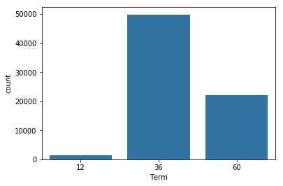

```python
#plot countplot of loans disbursed for each Term
base_color = sb.color_palette()[0]
sb.countplot(data=loan_data1, x = 'Term', color=base_color);
```

> There were more loans disbursed for a 36 months term

#### Q2. What is the distribution of the Loan Original Amount.

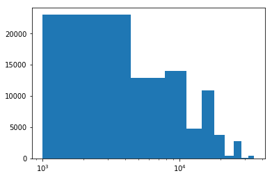

```python
#Plot histogram of original amount on the logarithmic scale.
plt.hist(data=loan_data1, x = 'LoanOriginalAmount')
plt.xscale('log');
```

```python
#Find the limits to the 10th Log
np.log10(loan_data1['LoanOriginalAmount'].describe())
```

```
count    4.865086
mean     3.971227
std      3.808238
min      3.000000
25%      3.602060
50%      3.903090
75%      4.176091
max      4.544068
Name: LoanOriginalAmount, dtype: float64
```

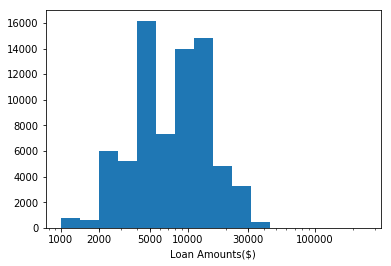

```python
#Replot log scaled histogram with appropriate xticks.
bins = 10 ** np.arange(3, 4.5+1, 0.15)
ticks = [1000, 2000, 5000, 10000, 30000, 100000]
labels = ['{}'.format(v) for v in ticks]
plt.hist(data=loan_data1, x = 'LoanOriginalAmount', bins=bins)
plt.xscale('log')
plt.xlabel('Loan Amounts($)')
plt.xticks(ticks, labels);
```

> The Bar chart appears to be bimodal with a peak around 4k and 5k and the other somewhere around 9k and 15k.

#### Q3. What is the distribution of Loan Status.

```python
gen_order = loan_data1['LoanStatus'].value_counts().index
loanstat_count = loan_data1['LoanStatus'].value_counts()

n_loans = loan_data1.shape[0]
max_loanstat_count = loanstat_count[0]
max_prop = max_loanstat_count / n_loans

tick_props = np.arange(0, max_prop, 0.06)
tick_names = ['{:0.2f}'.format(v) for v in tick_props]
```

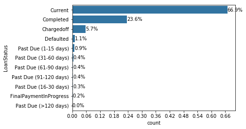

```python
gen_order = loan_data1['LoanStatus'].value_counts().index
base_color = sb.color_palette()[0]
sb.countplot(data=loan_data1, y = 'LoanStatus', order = gen_order,color = base_color);
plt.xticks(tick_props * n_loans, tick_names);

for i in range(loanstat_count.shape[0]):
    count = loanstat_count[i]
    pct_string = '{:0.1f}%'.format(100*count/n_loans)
    plt.text(count+1, i, pct_string, va='center');
```

> 23% completed the loans while 1.1% defaulted.

#### Q4. What is the distribution of the Stated Monthly Income.

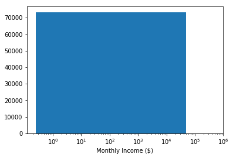

```python
#Plot a histogram for stated monthly income on the logarithmic scale
plt.hist(data=loan_data1, x = 'StatedMonthlyIncome')
plt.xscale('log')
plt.xlabel('Monthly Income ($)');
```

```python
#Find the limits to the 10th Log
np.log10(loan_data1['StatedMonthlyIncome'].describe())
```

```
count    4.865086
mean     3.783703
std      3.712830
min     -0.602060
25%      3.564271
50%      3.713210
75%      3.865301
max      5.684247
Name: StatedMonthlyIncome, dtype: float64
```

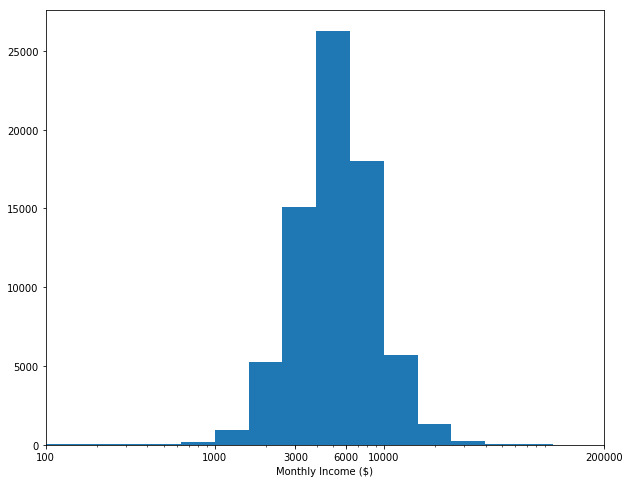

```python
#Replot log scaled histogram with appropriate xticks.
plt.figure(figsize=[10,8])
bins = 10 ** np.arange(-0.6, 5.6+1, 0.2)
ticks = [1, 10, 100, 1000, 3000, 6000, 10000, 200000,500000]
labels = ['{}'.format(v) for v in ticks]
plt.hist(data=loan_data1, x = 'StatedMonthlyIncome', bins=bins)
plt.xscale('log')
plt.xticks(ticks, labels)
plt.xlim(100,200000);
plt.xlabel('Monthly Income ($)');
```

> This is a unimodal distribution with the peak around 4000 and 6000.

#### Q5: In what year were more loans booked?

```python
#Create new feature to extract Loan year
loan_data1['LoanYear'] = loan_data1['LoanOriginationDate'].dt.year
```

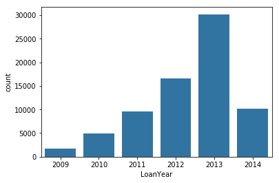

```python
sb.countplot(data = loan_data1, x='LoanYear', color=base_color);
```

> Loans booked continues to grow from 2009 and peaked in 2013 after which it dropped in 2014.

### Discuss the distribution(s) of your variable(s) of interest. Were there any unusual points? Did you need to perform any transformations?

> The plot for the Loan Original amount showed an unusual pattern. There was a jump in the count of borrowers that took between 4,000 to 5,000 and dipped after 5,000. There was also another jump in the number of borrowers that took beween 8,000 and 16,000 in loans

### Of the features you investigated, were there any unusual distributions? Did you perform any operations on the data to tidy, adjust, or change the form of the data? If so, why did you do this?

> The plot to show the year of loan disbursal showed a sharp drop in 2014 after the count grew steadily from 2009 t0 2013.

## Bivariate Exploration

> In this section, investigate relationships between pairs of variables in your data. Make sure the variables that you cover here have been introduced in some fashion in the previous section (univariate exploration).

#### Q6: Which loan amounts had the best yield?

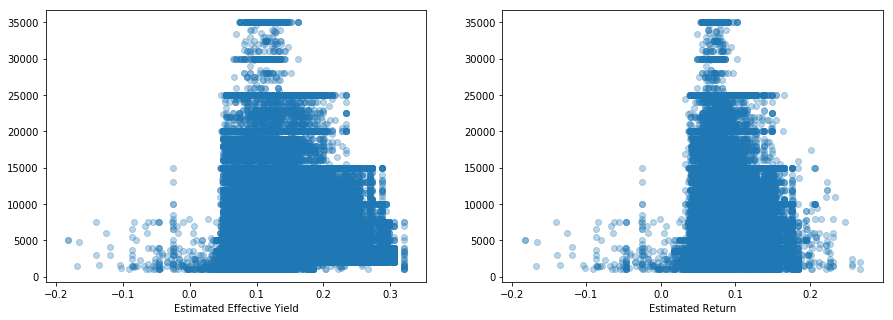

```python
plt.figure(figsize=[15,5])

plt.subplot(1,2,1)
plt.scatter(data=loan_data1, x = 'EstimatedEffectiveYield', y='LoanOriginalAmount', alpha=0.3);
plt.xlabel('Estimated Effective Yield');

plt.subplot(1,2,2)
plt.scatter(data=loan_data1, x = 'EstimatedReturn', y='LoanOriginalAmount', alpha=0.3);
plt.xlabel('Estimated Return');
```

> Loan amounts below 15,000 gave the best yield.

#### Q7: Find the distribution of emploment status of loans from the three unique Terms?

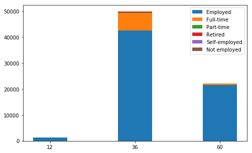

```python
term_order = [12, 36, 60]
employment_order = ['Employed', 'Full-time', 'Part-time', 'Retired','Self-employed','Not employed']

plt.figure(figsize = [8, 5])

# right plot: stacked bar chart,

baselines = np.zeros(len(term_order))
# for each second-variable category:
for i in range(len(employment_order)):
    # isolate the counts of the first category,
    emp2 = employment_order[i]
    inner_counts = loan_data1[loan_data1['EmploymentStatus'] == emp2]['Term'].value_counts()
    # then plot those counts on top of the accumulated baseline
    plt.bar(x = np.arange(len(term_order)), height = inner_counts[term_order],
            bottom = baselines, width=0.4)
    baselines += inner_counts[term_order]

plt.xticks(np.arange(len(term_order)), term_order)
plt.legend(employment_order);
```

> Borrowers in the employed category had the most number of borrowers among all the listed employment status

#### Q8: Find the correlation between `Employment Status` and `Loan Original Amount`.

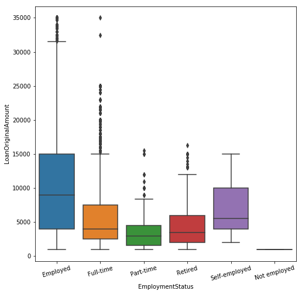

```python
plt.figure(figsize=[8,8])
sb.boxplot(data=loan_data1, x='EmploymentStatus', y='LoanOriginalAmount')
plt.xticks(rotation=15);
```

> The 'Not Employed category has the least mean value followed by 'Part Time'. While the employed category has the highest mean value of amount borrowed.

#### Q9: What is the size of loans disbursed by the unique Term for each year?

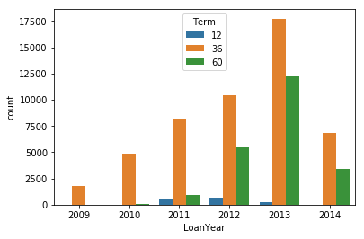

```python
sb.countplot(data=loan_data1, x='LoanYear', hue='Term');
```

> There are more loans with tenor of 60 months booked in 2013 which dropped in 2014.

#### Q10: What is the size of every loan status within the three unique Terms?

```python
dt_counts = loan_data1.groupby(['LoanStatus','Term']).size()
dt_counts = dt_counts.reset_index(name='count')
dt_counts = dt_counts.pivot(columns='Term',index='LoanStatus', values='count').fillna(0)
```

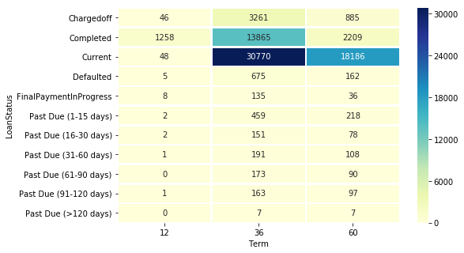

```python
plt.figure(figsize=[8,5])
sb.heatmap(dt_counts,cmap="YlGnBu",linewidths=1.5, annot=True, fmt='.0f');
```

> There were much more loans in the current category for 36 and 60 months compared to the completed loans. This is in sharp contrast to same attributes in the 12 month tenure.

#### Q11: What is the relationship between `EmploymentStatus` and the `BorrowerAPR`.

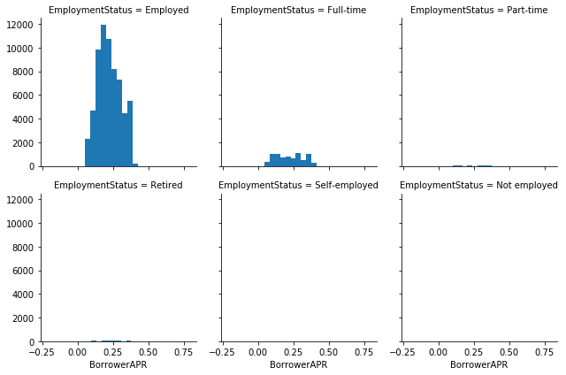

```python
a = sb.FacetGrid(data=loan_data1, col='EmploymentStatus', col_wrap=3)
a.map(plt.hist,'BorrowerAPR');
```

#### Q12: What is the relationship between LoanOriginalAmount and the BorrowerAPR.

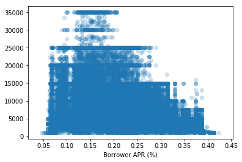

```python
plt.scatter(data=loan_data1, x='BorrowerAPR',y='LoanOriginalAmount', alpha=0.2)
plt.xlabel('Borrower APR (%)');
```

### Did you observe any interesting relationships between the other features (not the main feature(s) of interest)?

> Current loans with 12 months Term seem to be less favoured when compared to those of 36 and 60 Months.

## Multivariate Exploration

> Create plots of three or more variables to investigate your data even further. Make sure that your investigations are justified, and follow from your work in the previous sections.

#### Q13: What is the relationship between LoanOriginalAmount and the BorrowerAPR.

```python
#Seeding random choiced generator
np.random.seed(2000)
sample = np.random.choice(loan_data1.shape[0], 500, replace=False)
loan_data1_subset = loan_data1.loc[sample]
```

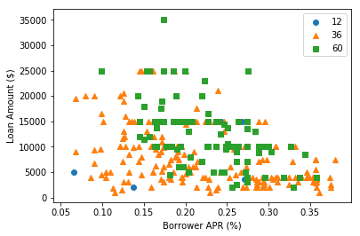

```python
#Defining shape markers
term_markers = [[12, 'o'],
                [36, '^'],
                [60, 's']]

for term1, marker in term_markers:
    df_term = loan_data1_subset.loc[loan_data1_subset['Term'] == term1]
    plt.scatter(data = df_term, x = 'BorrowerAPR', y = 'LoanOriginalAmount', marker = marker)
plt.legend(['12','36','60'])
plt.xlabel('Borrower APR (%)')
plt.ylabel('Loan Amount ($)');
```

#### Q14: What is the relationship between LoanOriginalAmount and the BorrowerAPR.

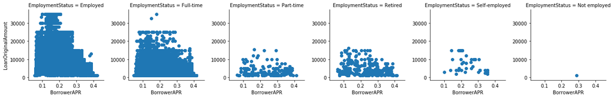

```python
#Plot facetGrid showing the pair of BorrowerAPR-LoanOriginalAmount for each Employment Status
g = sb.FacetGrid(data=loan_data1, col='EmploymentStatus')
g.map(plt.scatter, 'BorrowerAPR','LoanOriginalAmount');
```

> Borrowers within Part-time, Retired and Self-employed category did not get more than 20,000. There were also fewer in number

#### Q15: Heat map to show the correlation of all numeric data.

```python
#Defining the columns of interest
loan_stats = ['LoanOriginalAmount', 'BorrowerAPR', 'Term','EmploymentStatusDuration','EstimatedReturn','DebtToIncomeRatio','StatedMonthlyIncome','ProsperScore']
```

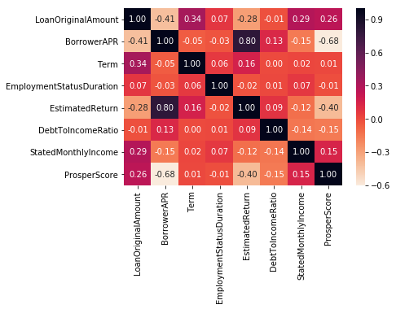

```python
#Plot heatmap with columns of interest.
sb.heatmap(loan_data1[loan_stats].corr(), cmap='rocket_r', annot=True, fmt='.2f', vmin=-0.6);
```

### Talk about some of the relationships you observed in this part of the investigation. Were there features that strengthened each other in terms of looking at your feature(s) of interest?

> There is some correlation between Loan original Amount and Term. The pair of Loan Original Amount and Stated Monthly income showed a fair degree of correlation. The Estimated Return is also hugely influence by the Borrower APR.

## Conclusions

> You can write a summary of the main findings and reflect on the steps taken during the data exploration.

> The prosper Loan Data had lots of columns many of which are generally redundant for this analysis. Firstly, i had to identify the dependent variables in Loan Original amount and Borrower APR and that guided me towards the relevant independant variables which saw the number of columns cut down to 17. The Data had quality issues in missing data and wrong format for Loan Origination Year. The refined dataframe for the analysis also was rid of 'Other' category within the employment status. The Size was the largest there there was literally no way to explain the makeup.